# DTM Evaluation — rr 2022-05-14

May 21, 2026

## Overview

**Site:** rr | **Date:** 2022-05-14 | **DTMs evaluated:** 4 | **ECPs (overall):** 169

ECP counts by class (Logger Array excluded).

| Vegetation class | n |
| --- | --- |
| 3 | 36 |
| 1 | 26 |
| 9 | 22 |
| 5 | 19 |
| 6 | 15 |
| 8 | 14 |
| 11 | 8 |
| 12 | 8 |
| 4 | 8 |
| 7 | 7 |
| 2 | 4 |
| 10 | 1 |
| N/A | 1 |

> **Note:** The following DTMs have a mean vertical bias statistically distinguishable from zero (t-test p < 0.05): csf_th0.005_res0.05_rgd2_0.25m, csf_th0.01_res0.1_rgd2_0.25m, csf_th0.06_res0.1_rgd2_0.25m, csf_th0.12_res0.2_rgd2_0.25m . Check the residual plots for systematic patterns.

### Overall RMSE

| DTM | n | Bias (m) | RMSE (m) | MAE (m) | pct_within_10cm | pct_within_20cm |
| --- | --- | --- | --- | --- | --- | --- |
| csf_th0.01_res0.1_rgd2_0.25m | 169 | 0.165 | 0.174 | 0.167 | 6.5 | 75.7 |
| csf_th0.06_res0.1_rgd2_0.25m | 169 | 0.170 | 0.179 | 0.171 | 5.3 | 74.6 |
| csf_th0.005_res0.05_rgd2_0.25m | 169 | 0.172 | 0.181 | 0.172 | 5.9 | 74.6 |
| csf_th0.12_res0.2_rgd2_0.25m | 169 | 0.168 | 0.181 | 0.172 | 6.5 | 73.4 |

## Full metrics table

All metric columns, all DTMs and classes.

| dtm | group | n | mean_bias | median_bias | mae | mad | rmse | max_abs | q25_abs | q75_abs | q95_abs | slope | bias_p | pct_within_10cm | pct_within_20cm |
| --- | --- | --- | --- | --- | --- | --- | --- | --- | --- | --- | --- | --- | --- | --- | --- |
| csf_th0.005_res0.05_rgd2_0.25m | overall | 169 | 0.172 | 0.163 | 0.172 | 0.051 | 0.181 | 0.337 | 0.137 | 0.203 | 0.274 | 0.955 | 0.000 | 5.9 | 74.6 |
| csf_th0.01_res0.1_rgd2_0.25m | overall | 169 | 0.165 | 0.162 | 0.167 | 0.049 | 0.174 | 0.332 | 0.133 | 0.197 | 0.256 | 0.958 | 0.000 | 6.5 | 75.7 |
| csf_th0.06_res0.1_rgd2_0.25m | overall | 169 | 0.170 | 0.168 | 0.171 | 0.049 | 0.179 | 0.374 | 0.133 | 0.201 | 0.260 | 0.951 | 0.000 | 5.3 | 74.6 |
| csf_th0.12_res0.2_rgd2_0.25m | overall | 169 | 0.168 | 0.170 | 0.172 | 0.053 | 0.181 | 0.380 | 0.135 | 0.207 | 0.271 | 0.961 | 0.000 | 6.5 | 73.4 |
| csf_th0.005_res0.05_rgd2_0.25m | 1 | 26 | 0.195 | 0.196 | 0.195 | 0.053 | 0.202 | 0.270 | 0.163 | 0.230 | 0.266 | 0.840 | 0.000 | 3.8 | 53.8 |
| csf_th0.01_res0.1_rgd2_0.25m | 1 | 26 | 0.181 | 0.186 | 0.187 | 0.039 | 0.191 | 0.257 | 0.162 | 0.219 | 0.232 | 0.881 | 0.000 | 3.8 | 53.8 |
| csf_th0.06_res0.1_rgd2_0.25m | 1 | 26 | 0.190 | 0.197 | 0.194 | 0.047 | 0.200 | 0.266 | 0.168 | 0.229 | 0.257 | 0.841 | 0.000 | 3.8 | 53.8 |
| csf_th0.12_res0.2_rgd2_0.25m | 1 | 26 | 0.176 | 0.208 | 0.200 | 0.039 | 0.209 | 0.321 | 0.182 | 0.232 | 0.266 | 0.743 | 0.000 | 7.7 | 42.3 |
| csf_th0.005_res0.05_rgd2_0.25m | 10 | 1 | 0.067 | 0.067 | 0.067 | 0.000 | 0.067 | 0.067 | 0.067 | 0.067 | 0.067 | NA | NA | 100.0 | 100.0 |
| csf_th0.01_res0.1_rgd2_0.25m | 10 | 1 | 0.076 | 0.076 | 0.076 | 0.000 | 0.076 | 0.076 | 0.076 | 0.076 | 0.076 | NA | NA | 100.0 | 100.0 |
| csf_th0.06_res0.1_rgd2_0.25m | 10 | 1 | 0.067 | 0.067 | 0.067 | 0.000 | 0.067 | 0.067 | 0.067 | 0.067 | 0.067 | NA | NA | 100.0 | 100.0 |
| csf_th0.12_res0.2_rgd2_0.25m | 10 | 1 | 0.067 | 0.067 | 0.067 | 0.000 | 0.067 | 0.067 | 0.067 | 0.067 | 0.067 | NA | NA | 100.0 | 100.0 |
| csf_th0.005_res0.05_rgd2_0.25m | 11 | 8 | 0.253 | 0.273 | 0.253 | 0.040 | 0.260 | 0.337 | 0.224 | 0.286 | 0.323 | 1.038 | 0.000 | 0.0 | 25.0 |
| csf_th0.01_res0.1_rgd2_0.25m | 11 | 8 | 0.241 | 0.258 | 0.241 | 0.067 | 0.248 | 0.312 | 0.192 | 0.286 | 0.306 | 1.154 | 0.000 | 0.0 | 25.0 |
| csf_th0.06_res0.1_rgd2_0.25m | 11 | 8 | 0.251 | 0.263 | 0.251 | 0.063 | 0.258 | 0.340 | 0.204 | 0.297 | 0.326 | 1.169 | 0.000 | 0.0 | 25.0 |
| csf_th0.12_res0.2_rgd2_0.25m | 11 | 8 | 0.243 | 0.258 | 0.243 | 0.063 | 0.249 | 0.303 | 0.203 | 0.290 | 0.302 | 1.387 | 0.000 | 0.0 | 25.0 |
| csf_th0.005_res0.05_rgd2_0.25m | 12 | 8 | 0.182 | 0.168 | 0.182 | 0.052 | 0.194 | 0.336 | 0.137 | 0.195 | 0.298 | 0.123 | 0.000 | 0.0 | 75.0 |
| csf_th0.01_res0.1_rgd2_0.25m | 12 | 8 | 0.181 | 0.161 | 0.181 | 0.057 | 0.193 | 0.332 | 0.138 | 0.206 | 0.292 | 0.233 | 0.000 | 0.0 | 62.5 |
| csf_th0.06_res0.1_rgd2_0.25m | 12 | 8 | 0.196 | 0.169 | 0.196 | 0.062 | 0.211 | 0.374 | 0.141 | 0.228 | 0.323 | 0.090 | 0.000 | 0.0 | 62.5 |
| csf_th0.12_res0.2_rgd2_0.25m | 12 | 8 | 0.202 | 0.176 | 0.202 | 0.062 | 0.216 | 0.380 | 0.142 | 0.232 | 0.330 | 0.080 | 0.000 | 0.0 | 62.5 |
| csf_th0.005_res0.05_rgd2_0.25m | 2 | 4 | 0.247 | 0.254 | 0.247 | 0.022 | 0.248 | 0.273 | 0.235 | 0.266 | 0.272 | 1.208 | 0.000 | 0.0 | 0.0 |
| csf_th0.01_res0.1_rgd2_0.25m | 2 | 4 | 0.244 | 0.254 | 0.244 | 0.016 | 0.245 | 0.265 | 0.234 | 0.264 | 0.265 | 1.214 | 0.000 | 0.0 | 0.0 |
| csf_th0.06_res0.1_rgd2_0.25m | 2 | 4 | 0.241 | 0.250 | 0.241 | 0.018 | 0.243 | 0.265 | 0.231 | 0.260 | 0.264 | 1.198 | 0.000 | 0.0 | 0.0 |
| csf_th0.12_res0.2_rgd2_0.25m | 2 | 4 | 0.230 | 0.247 | 0.230 | 0.020 | 0.234 | 0.268 | 0.219 | 0.257 | 0.266 | 1.221 | 0.003 | 0.0 | 25.0 |
| csf_th0.005_res0.05_rgd2_0.25m | 3 | 36 | 0.136 | 0.127 | 0.136 | 0.034 | 0.143 | 0.275 | 0.106 | 0.150 | 0.224 | 0.980 | 0.000 | 16.7 | 91.7 |
| csf_th0.01_res0.1_rgd2_0.25m | 3 | 36 | 0.132 | 0.130 | 0.132 | 0.033 | 0.139 | 0.275 | 0.106 | 0.146 | 0.215 | 0.986 | 0.000 | 16.7 | 91.7 |
| csf_th0.06_res0.1_rgd2_0.25m | 3 | 36 | 0.134 | 0.133 | 0.134 | 0.032 | 0.141 | 0.275 | 0.109 | 0.149 | 0.215 | 0.992 | 0.000 | 16.7 | 91.7 |
| csf_th0.12_res0.2_rgd2_0.25m | 3 | 36 | 0.135 | 0.133 | 0.135 | 0.031 | 0.142 | 0.275 | 0.109 | 0.149 | 0.217 | 0.990 | 0.000 | 16.7 | 91.7 |
| csf_th0.005_res0.05_rgd2_0.25m | 4 | 8 | 0.146 | 0.140 | 0.146 | 0.022 | 0.148 | 0.205 | 0.127 | 0.153 | 0.190 | 0.928 | 0.000 | 0.0 | 87.5 |
| csf_th0.01_res0.1_rgd2_0.25m | 4 | 8 | 0.146 | 0.141 | 0.146 | 0.031 | 0.149 | 0.210 | 0.122 | 0.156 | 0.196 | 0.901 | 0.000 | 0.0 | 87.5 |
| csf_th0.06_res0.1_rgd2_0.25m | 4 | 8 | 0.149 | 0.142 | 0.149 | 0.021 | 0.152 | 0.218 | 0.128 | 0.155 | 0.201 | 0.919 | 0.000 | 0.0 | 87.5 |
| csf_th0.12_res0.2_rgd2_0.25m | 4 | 8 | 0.148 | 0.141 | 0.148 | 0.020 | 0.151 | 0.218 | 0.128 | 0.150 | 0.201 | 0.911 | 0.000 | 0.0 | 87.5 |
| csf_th0.005_res0.05_rgd2_0.25m | 5 | 19 | 0.172 | 0.173 | 0.172 | 0.023 | 0.175 | 0.225 | 0.159 | 0.185 | 0.225 | 0.875 | 0.000 | 0.0 | 84.2 |
| csf_th0.01_res0.1_rgd2_0.25m | 5 | 19 | 0.174 | 0.172 | 0.174 | 0.020 | 0.176 | 0.233 | 0.157 | 0.185 | 0.223 | 0.931 | 0.000 | 0.0 | 84.2 |
| csf_th0.06_res0.1_rgd2_0.25m | 5 | 19 | 0.170 | 0.175 | 0.170 | 0.020 | 0.172 | 0.220 | 0.158 | 0.186 | 0.220 | 0.885 | 0.000 | 0.0 | 89.5 |
| csf_th0.12_res0.2_rgd2_0.25m | 5 | 19 | 0.170 | 0.175 | 0.170 | 0.020 | 0.172 | 0.221 | 0.158 | 0.186 | 0.220 | 0.885 | 0.000 | 0.0 | 89.5 |
| csf_th0.005_res0.05_rgd2_0.25m | 6 | 15 | 0.156 | 0.163 | 0.156 | 0.039 | 0.159 | 0.206 | 0.128 | 0.174 | 0.199 | 0.928 | 0.000 | 0.0 | 93.3 |
| csf_th0.01_res0.1_rgd2_0.25m | 6 | 15 | 0.155 | 0.162 | 0.155 | 0.035 | 0.158 | 0.203 | 0.131 | 0.171 | 0.198 | 0.923 | 0.000 | 0.0 | 93.3 |
| csf_th0.06_res0.1_rgd2_0.25m | 6 | 15 | 0.159 | 0.163 | 0.159 | 0.041 | 0.162 | 0.206 | 0.138 | 0.185 | 0.201 | 0.897 | 0.000 | 0.0 | 93.3 |
| csf_th0.12_res0.2_rgd2_0.25m | 6 | 15 | 0.161 | 0.172 | 0.161 | 0.040 | 0.165 | 0.216 | 0.138 | 0.189 | 0.205 | 0.894 | 0.000 | 0.0 | 86.7 |
| csf_th0.005_res0.05_rgd2_0.25m | 7 | 7 | 0.164 | 0.165 | 0.164 | 0.042 | 0.168 | 0.233 | 0.135 | 0.182 | 0.221 | 0.888 | 0.000 | 0.0 | 85.7 |
| csf_th0.01_res0.1_rgd2_0.25m | 7 | 7 | 0.162 | 0.162 | 0.162 | 0.039 | 0.165 | 0.228 | 0.134 | 0.176 | 0.216 | 0.918 | 0.000 | 0.0 | 85.7 |
| csf_th0.06_res0.1_rgd2_0.25m | 7 | 7 | 0.164 | 0.164 | 0.164 | 0.035 | 0.168 | 0.235 | 0.136 | 0.178 | 0.221 | 0.886 | 0.000 | 0.0 | 85.7 |
| csf_th0.12_res0.2_rgd2_0.25m | 7 | 7 | 0.165 | 0.164 | 0.165 | 0.036 | 0.169 | 0.235 | 0.136 | 0.180 | 0.221 | 0.893 | 0.000 | 0.0 | 85.7 |
| csf_th0.005_res0.05_rgd2_0.25m | 8 | 14 | 0.169 | 0.176 | 0.169 | 0.025 | 0.172 | 0.225 | 0.147 | 0.192 | 0.204 | 0.745 | 0.000 | 0.0 | 92.9 |
| csf_th0.01_res0.1_rgd2_0.25m | 8 | 14 | 0.169 | 0.182 | 0.169 | 0.032 | 0.172 | 0.212 | 0.146 | 0.191 | 0.204 | 0.704 | 0.000 | 0.0 | 85.7 |
| csf_th0.06_res0.1_rgd2_0.25m | 8 | 14 | 0.167 | 0.178 | 0.167 | 0.030 | 0.169 | 0.219 | 0.146 | 0.183 | 0.203 | 0.657 | 0.000 | 0.0 | 92.9 |
| csf_th0.12_res0.2_rgd2_0.25m | 8 | 14 | 0.168 | 0.172 | 0.168 | 0.025 | 0.170 | 0.227 | 0.148 | 0.183 | 0.206 | 0.607 | 0.000 | 0.0 | 92.9 |
| csf_th0.005_res0.05_rgd2_0.25m | 9 | 22 | 0.192 | 0.182 | 0.192 | 0.062 | 0.200 | 0.307 | 0.154 | 0.235 | 0.278 | 0.923 | 0.000 | 4.5 | 59.1 |
| csf_th0.01_res0.1_rgd2_0.25m | 9 | 22 | 0.171 | 0.174 | 0.171 | 0.034 | 0.177 | 0.256 | 0.152 | 0.197 | 0.239 | 0.863 | 0.000 | 9.1 | 77.3 |
| csf_th0.06_res0.1_rgd2_0.25m | 9 | 22 | 0.183 | 0.174 | 0.183 | 0.051 | 0.189 | 0.259 | 0.155 | 0.214 | 0.258 | 0.884 | 0.000 | 0.0 | 59.1 |
| csf_th0.12_res0.2_rgd2_0.25m | 9 | 22 | 0.184 | 0.180 | 0.184 | 0.065 | 0.192 | 0.275 | 0.156 | 0.226 | 0.271 | 0.826 | 0.000 | 4.5 | 63.6 |
| csf_th0.005_res0.05_rgd2_0.25m | N/A | 1 | -0.019 | -0.019 | 0.019 | 0.000 | 0.019 | 0.019 | 0.019 | 0.019 | 0.019 | NA | NA | 100.0 | 100.0 |
| csf_th0.01_res0.1_rgd2_0.25m | N/A | 1 | -0.019 | -0.019 | 0.019 | 0.000 | 0.019 | 0.019 | 0.019 | 0.019 | 0.019 | NA | NA | 100.0 | 100.0 |
| csf_th0.06_res0.1_rgd2_0.25m | N/A | 1 | -0.018 | -0.018 | 0.018 | 0.000 | 0.018 | 0.018 | 0.018 | 0.018 | 0.018 | NA | NA | 100.0 | 100.0 |
| csf_th0.12_res0.2_rgd2_0.25m | N/A | 1 | -0.018 | -0.018 | 0.018 | 0.000 | 0.018 | 0.018 | 0.018 | 0.018 | 0.018 | NA | NA | 100.0 | 100.0 |

## Cross-DTM comparison

Predicted vs. observed elevation across all DTMs on a common scale, colored by vegetation class. Points near the 1:1 line indicate accurate DTM estimation; scatter above the line (predicted > observed) is typical where tall vegetation was not fully filtered.

### Standard plot

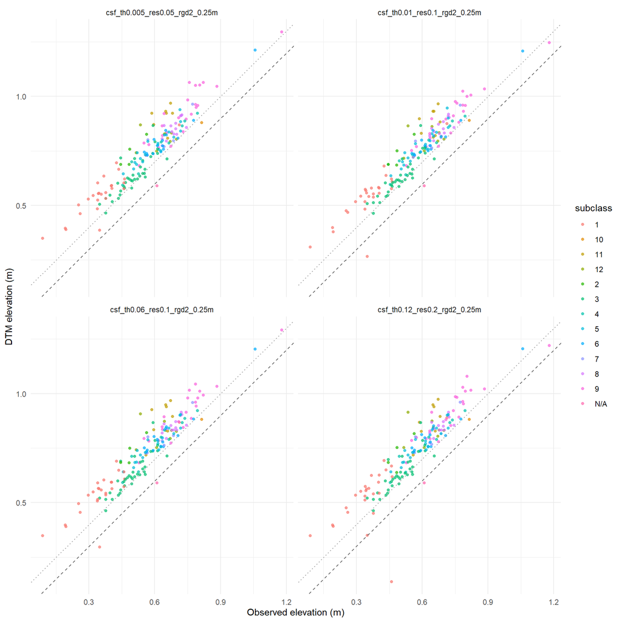

# With vegetation height indicated

Vertical lines stretch from the RTK field surveyed elevation to the top of the vegetation as recorded in the field, which may not be the height of the vegetation when the lidar was flown. Field work was conducted between 2022-08-06 and 2022-08-10.  
The lidar was flown on 2022-05-14

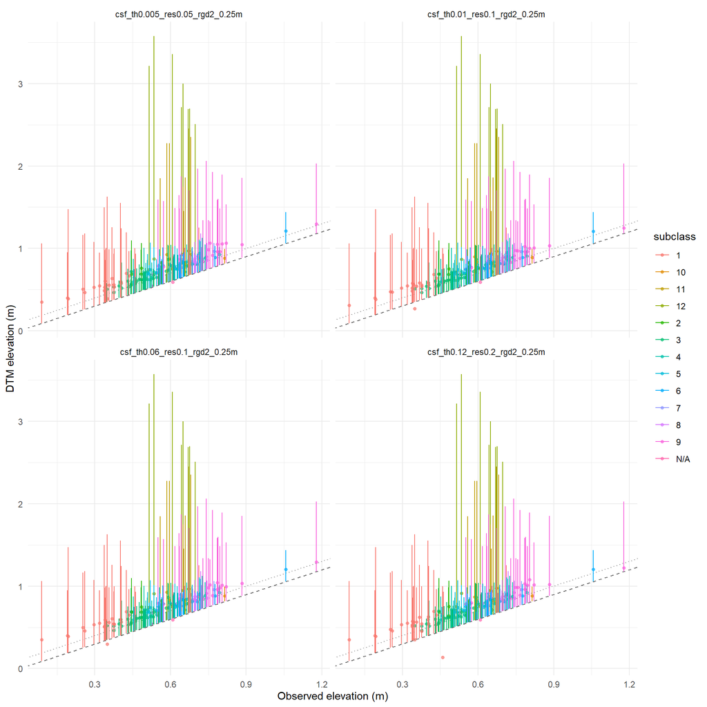

## Per-DTM plots

Five diagnostic plots per DTM. **Q-Q plot:** a straight line means residuals are roughly normal, which validates the t-test used for `bias_p`; heavy tails suggest using a sign test instead.

### csf_th0.005_res0.05_rgd2_0.25m

**Predicted vs observed**

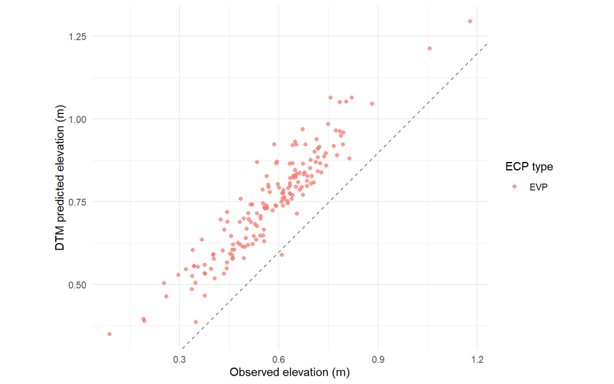

**Residual histogram**

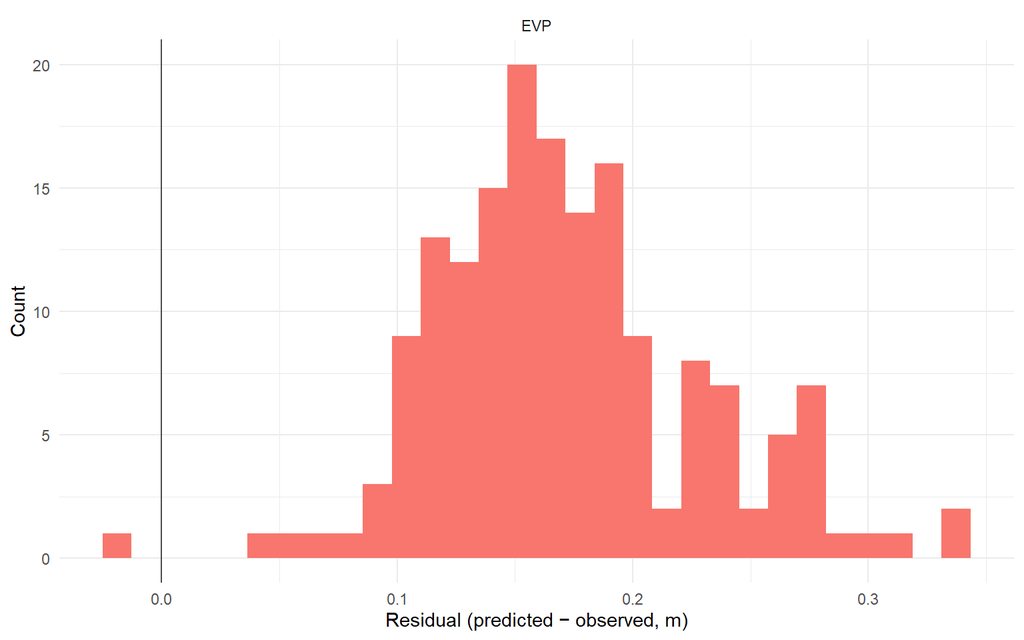

**Residual map**

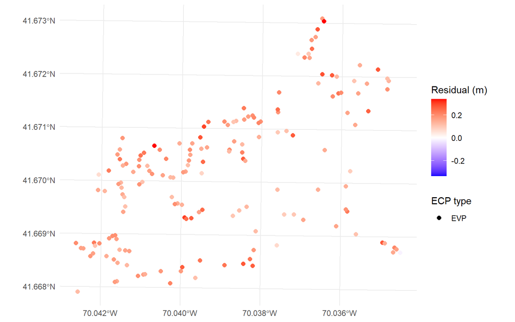

**Residual vs elevation**

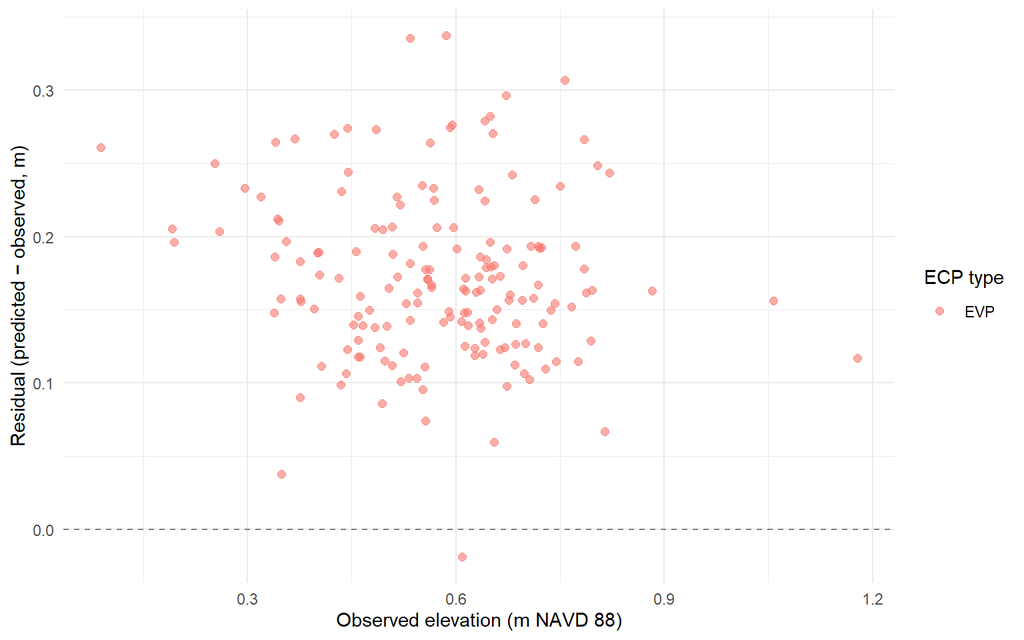

**Q-Q plot**

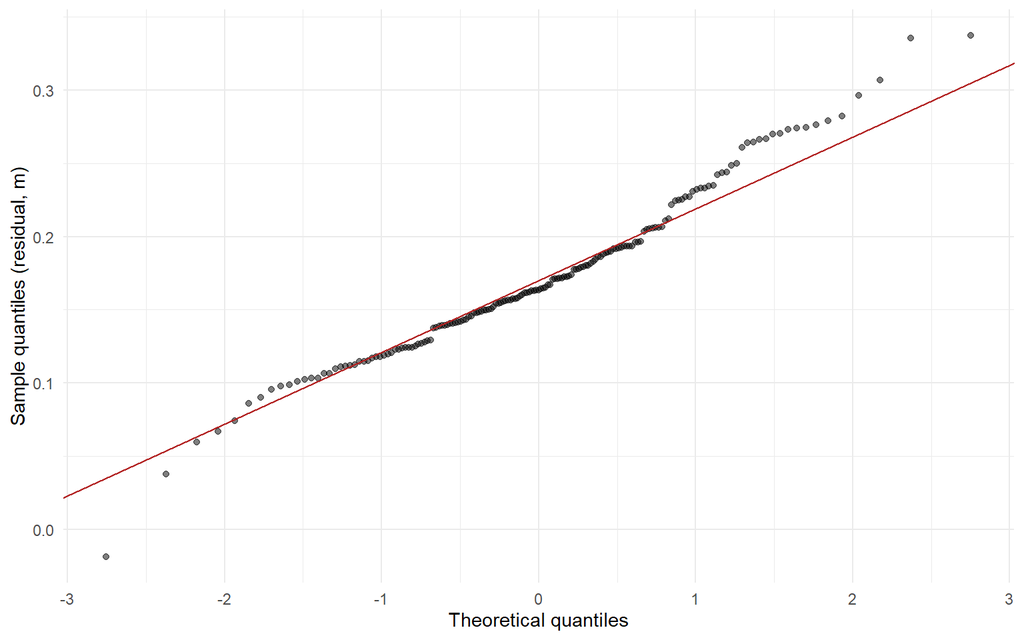

### csf_th0.01_res0.1_rgd2_0.25m

**Predicted vs observed**

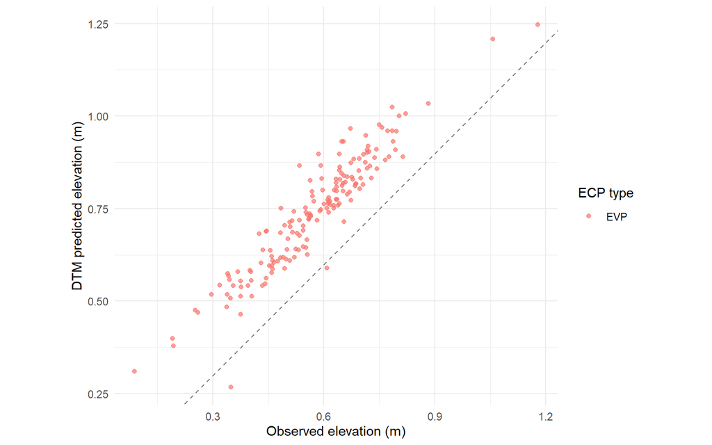

**Residual histogram**

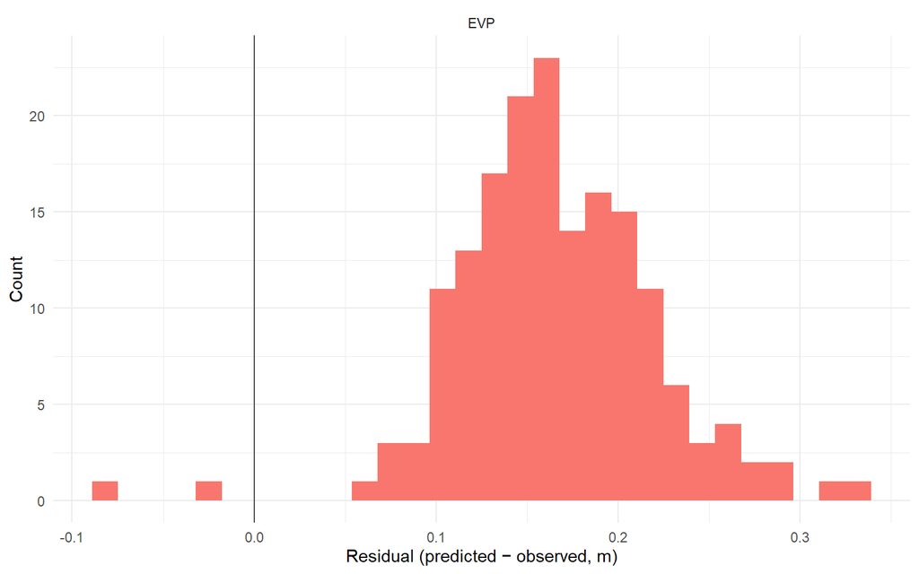

**Residual map**

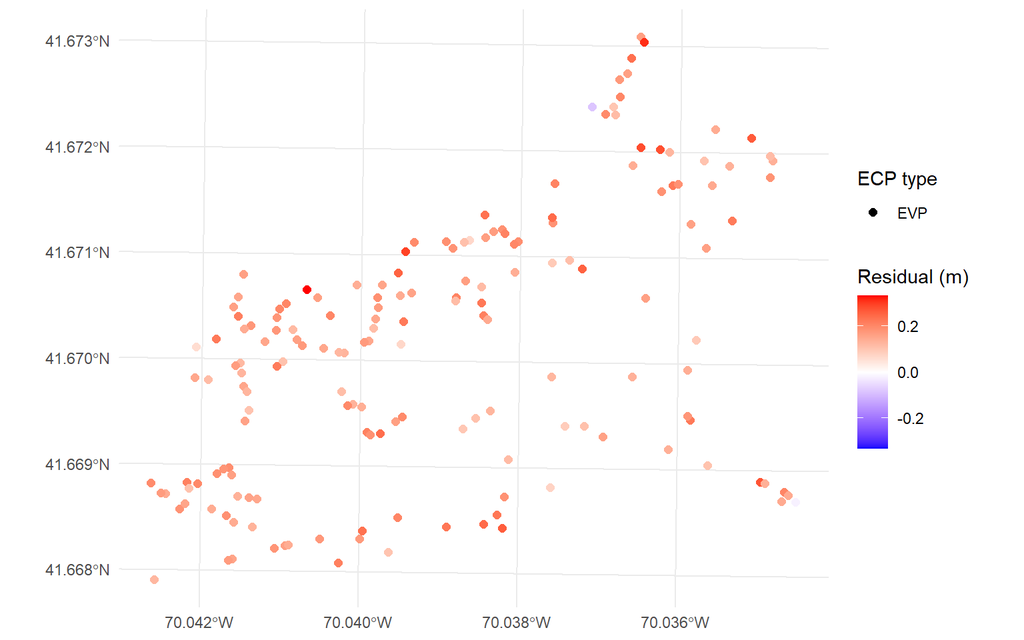

**Residual vs elevation**

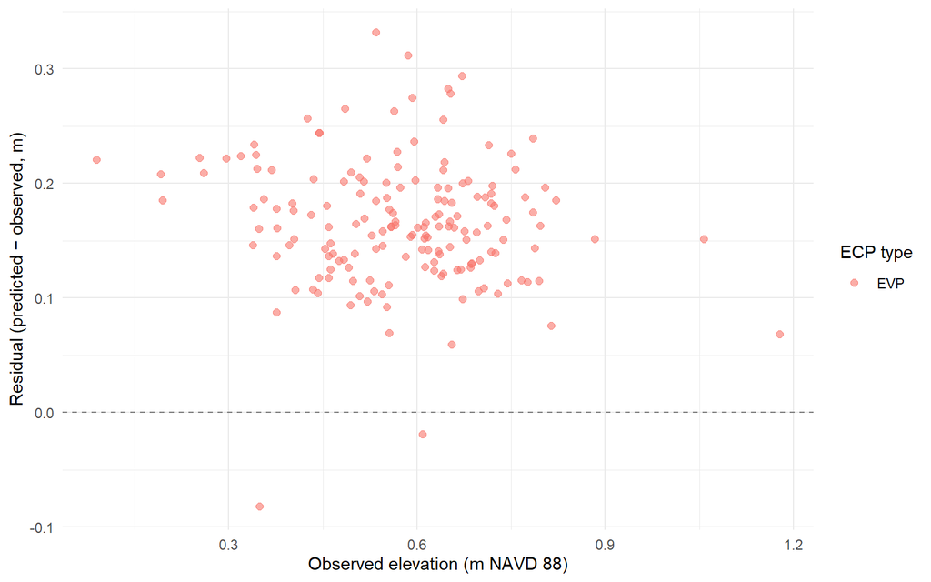

**Q-Q plot**

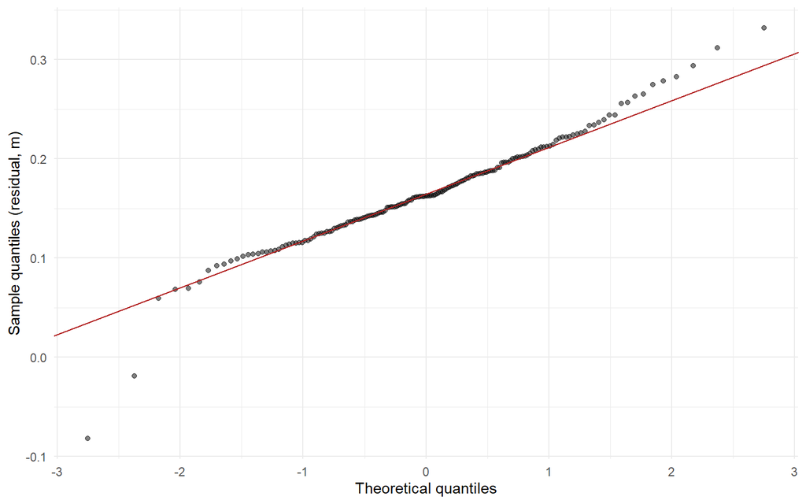

### csf_th0.06_res0.1_rgd2_0.25m

**Predicted vs observed**

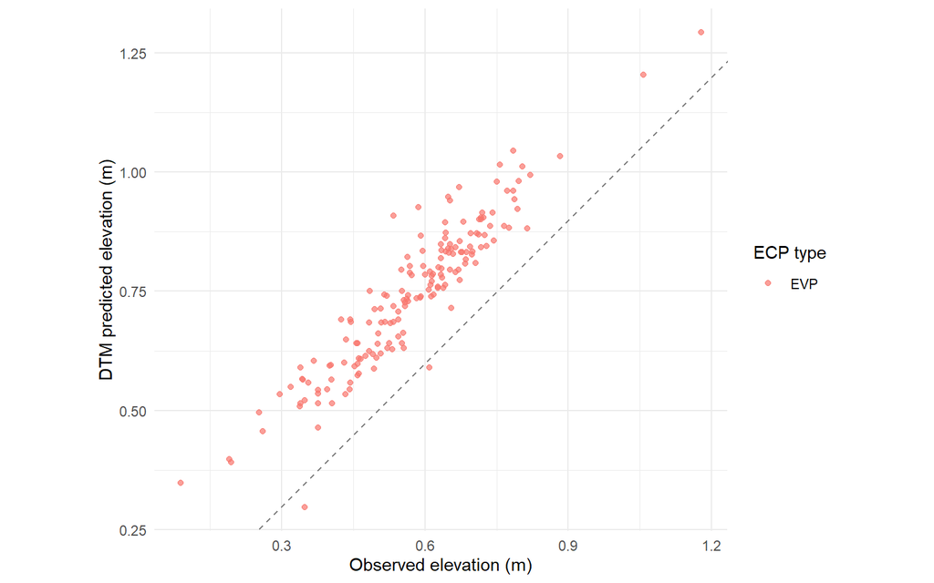

**Residual histogram**

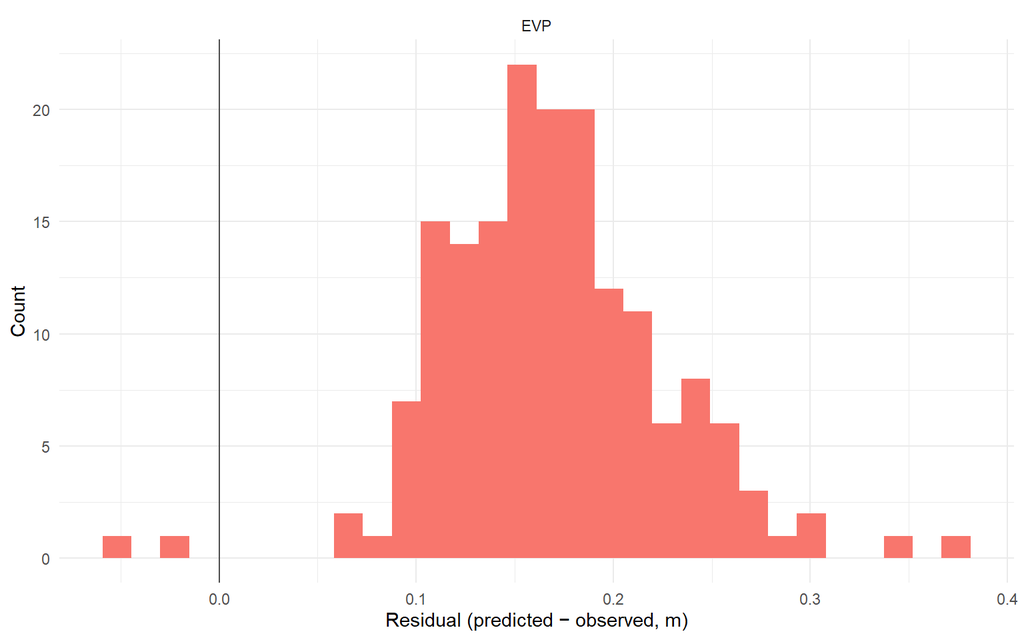

**Residual map**

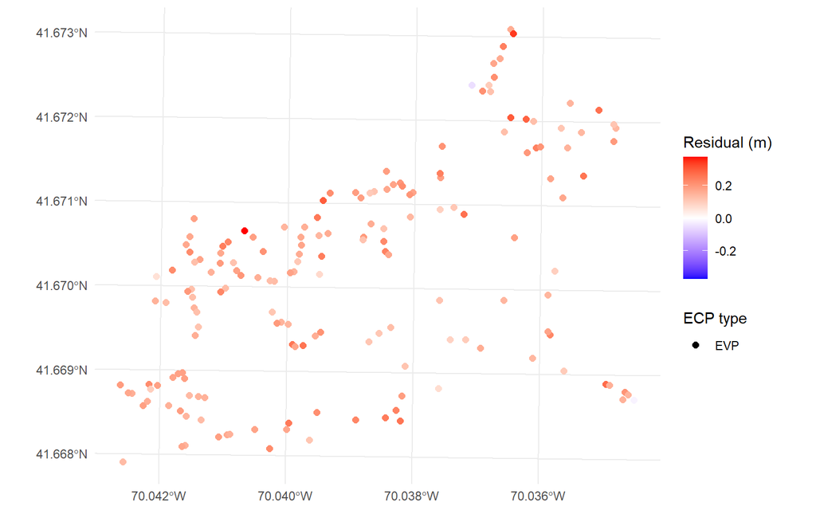

**Residual vs elevation**

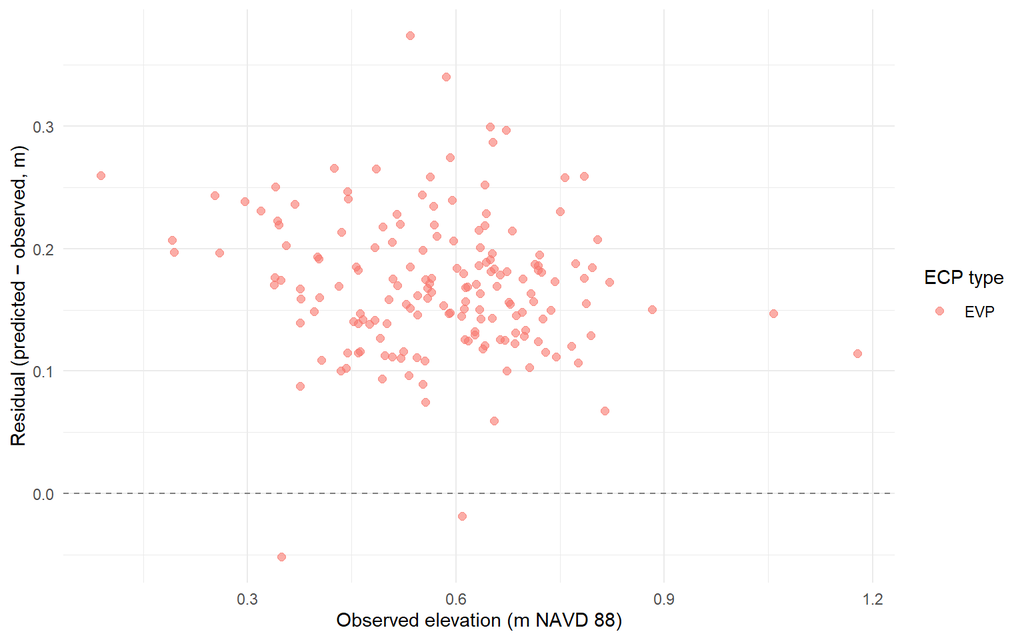

**Q-Q plot**

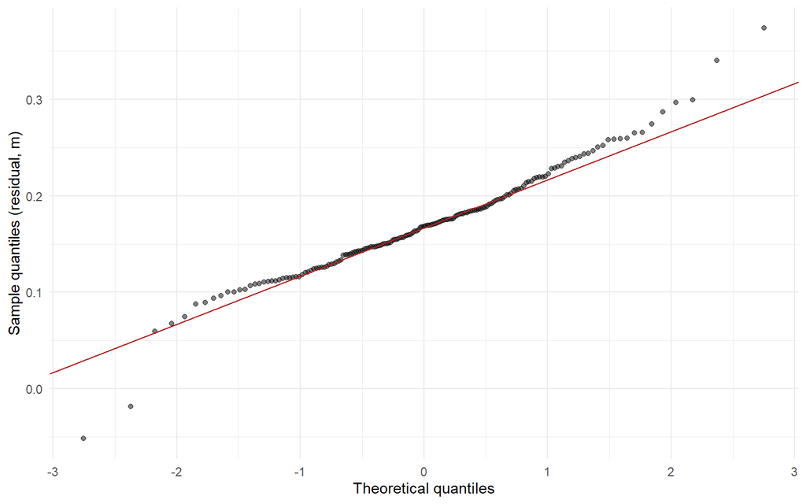

### csf_th0.12_res0.2_rgd2_0.25m

**Predicted vs observed**

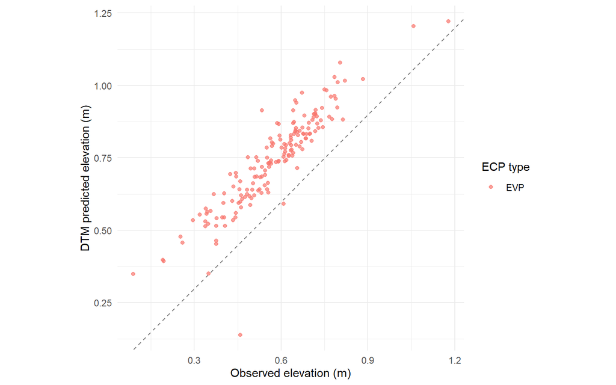

**Residual histogram**

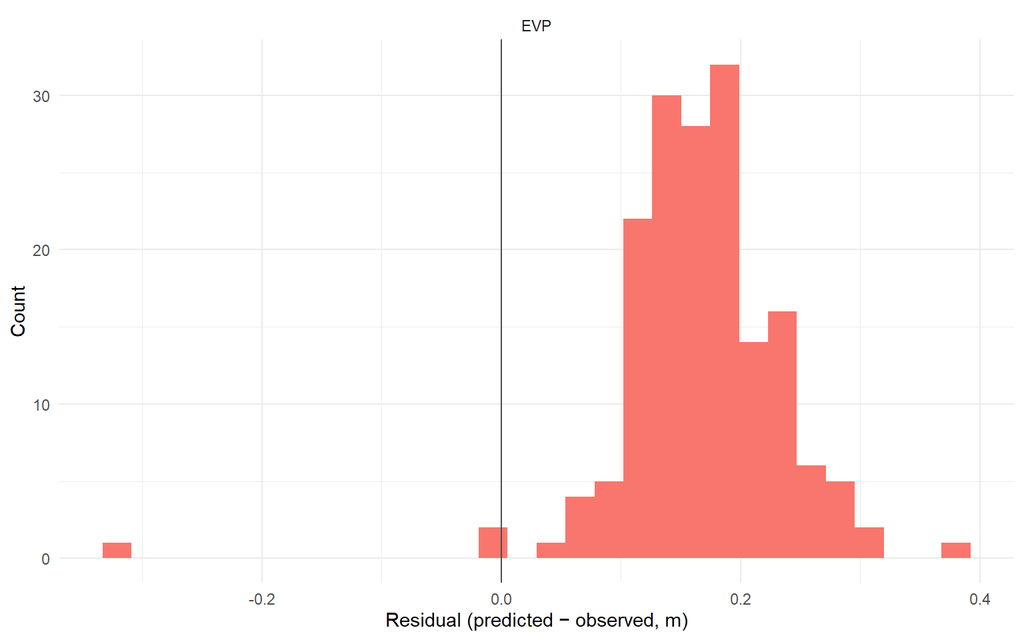

**Residual map**

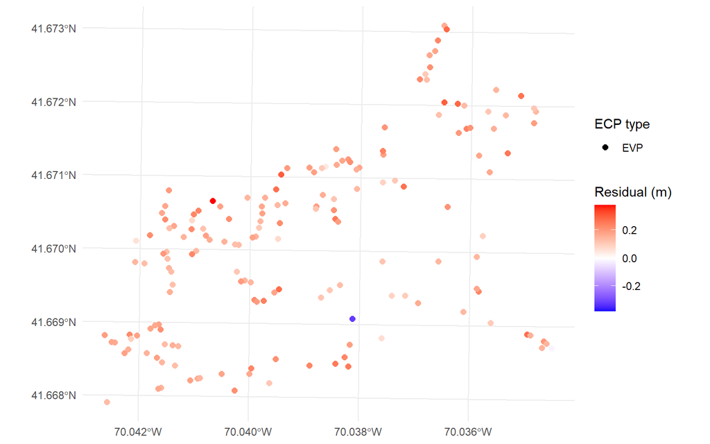

**Residual vs elevation**

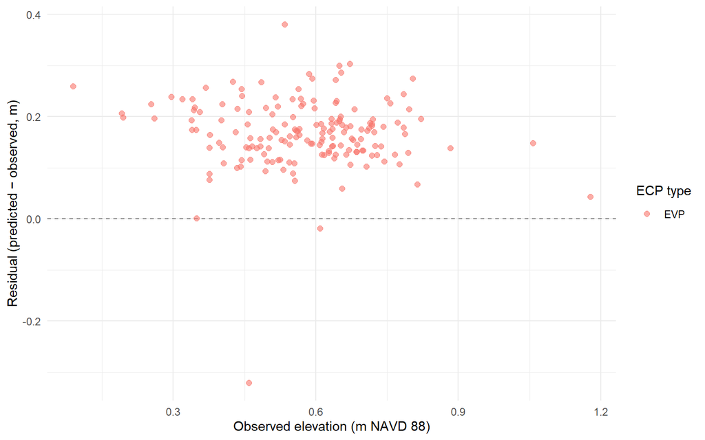

**Q-Q plot**

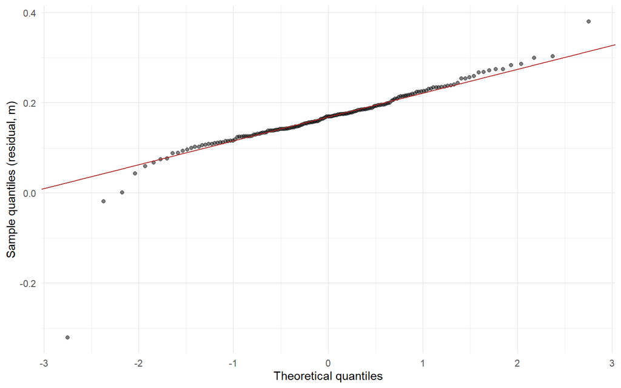